# DATA 605 - Discussion 12

Omer Ozeren

## Objective

Using R, build a multiple regression model for data that interests you. Include in this model at least one quadratic term, one dichotomous term, and one dichotomous vs. quantitative interaction term. Interpret all coefficients. Conduct residual analysis. Was the linear model appropriate? Why or why not?

I am using salary data that include observations on six variables for 52 tenure-track professors in a small college. The original data also can be found in “http://data.princeton.edu/wws509/datasets/”

The variables are:

- `sx`: Sex, coded 1 for female and 0 for male
- `rk`: Rank, coded 1 for assistant professor, 2 for associate professor, and 3 for full professor
- `yr`: Number of years in current rank
- `dg`: Highest degree, coded 1 if doctorate, 0 if masters
- `yd`: Number of years since highest degree was earned
- `sl`: Academic year salary, in dollars.

## Data Import

```r
# Data import
library(foreign)
salary <- read.dta("http://data.princeton.edu/wws509/datasets/salary.dta")
# Summary of Salary Data
summary(salary)
```

```
##       sx             rk           yr               dg
##  Male  :38   Assistant:18   Min.   : 0.000   Min.   :0.0000
##  Female:14   Associate:14   1st Qu.: 3.000   1st Qu.:0.0000
##              Full     :20   Median : 7.000   Median :1.0000
##                             Mean   : 7.481   Mean   :0.6538
##                             3rd Qu.:11.000   3rd Qu.:1.0000
##                             Max.   :25.000   Max.   :1.0000
##        yd              sl
##  Min.   : 1.00   Min.   :15000
##  1st Qu.: 6.75   1st Qu.:18247
##  Median :15.50   Median :23719
##  Mean   :16.12   Mean   :23798
##  3rd Qu.:23.25   3rd Qu.:27259
##  Max.   :35.00   Max.   :38045
```

```r
# Data sample
knitr::kable(head(salary))
```

| sx | rk | yr | dg | yd | sl |
| --- | --- | --- | --- | --- | --- |
| Male | Full | 25 | 1 | 35 | 36350 |
| Male | Full | 13 | 1 | 22 | 35350 |
| Male | Full | 10 | 1 | 23 | 28200 |
| Female | Full | 7 | 1 | 27 | 26775 |
| Male | Full | 19 | 0 | 30 | 33696 |
| Male | Full | 16 | 1 | 21 | 28516 |

## Data Engineering : Sex (`sx`) will be **dichotomous** variable.

Convert *sex* and *rank* into numerical representation.

```r
salary$sx <- as.character(salary$sx)
salary$sx[salary$sx == "Male"] <- 0
salary$sx[salary$sx == "Female"] <- 1
salary$sx <- as.integer(salary$sx)
salary$rk <- as.character(salary$rk)
salary$rk[salary$rk == "Assistant"] <- 1
salary$rk[salary$rk == "Associate"] <- 2
salary$rk[salary$rk == "Full"] <- 3
salary$rk <- as.integer(salary$rk)
```

## Iniitial Model

```r
# Quadratic variable
rk2 <- salary$rk^2
sx_yd <- salary$sx * salary$yd

# Initial model
salary_lm <- lm(sl ~ sx + rk + rk2 + yr + dg + yd + sx_yd, data=salary)
summary(salary_lm)
```

```
##
## Call:
## lm(formula = sl ~ sx + rk + rk2 + yr + dg + yd + sx_yd, data = salary)
##
## Residuals:
##     Min      1Q  Median      3Q     Max
## -3827.5 -1180.3  -288.7   844.7  8709.7
##
## Coefficients:
##             Estimate Std. Error t value Pr(>|t|)
## (Intercept) 13045.79    3302.80   3.950 0.000279 ***
## sx            127.83    1359.23   0.094 0.925502
## rk           4230.31    3530.16   1.198 0.237202
## rk2           340.06     845.99   0.402 0.689655
## yr            523.83     105.21   4.979 1.03e-05 ***
## dg          -1514.35    1024.89  -1.478 0.146645
## yd           -174.42      90.99  -1.917 0.061751 .
## sx_yd          80.00      76.74   1.042 0.302882
## ---
## Signif. codes:  0 '***' 0.001 '**' 0.01 '*' 0.05 '.' 0.1 ' ' 1
##
## Residual standard error: 2396 on 44 degrees of freedom
## Multiple R-squared:  0.8585, Adjusted R-squared:  0.836
## F-statistic: 38.15 on 7 and 44 DF,  p-value: < 2.2e-16
```

Perform **backwards elimination** - removing one variable (the one with highest p-value) at a time. Removing *sex*.

```r
# Version 2
salary_lm <- update(salary_lm, .~. -sx)
summary(salary_lm)
```

```
##
## Call:
## lm(formula = sl ~ rk + rk2 + yr + dg + yd + sx_yd, data = salary)
##
## Residuals:
##     Min      1Q  Median      3Q     Max
## -3822.3 -1186.7  -284.7   851.5  8710.6
##
## Coefficients:
##             Estimate Std. Error t value Pr(>|t|)
## (Intercept) 13159.28    3040.37   4.328 8.28e-05 ***
## rk           4142.04    3365.41   1.231   0.2248
## rk2           358.78     813.13   0.441   0.6612
## yr            523.94     104.04   5.036 8.16e-06 ***
## dg          -1506.10    1009.82  -1.491   0.1428
## yd           -175.51      89.24  -1.967   0.0554 .
## sx_yd          85.29      51.63   1.652   0.1055
## ---
## Signif. codes:  0 '***' 0.001 '**' 0.01 '*' 0.05 '.' 0.1 ' ' 1
##
## Residual standard error: 2370 on 45 degrees of freedom
## Multiple R-squared:  0.8585, Adjusted R-squared:  0.8396
## F-statistic: 45.51 on 6 and 45 DF,  p-value: < 2.2e-16
```

Removing *square of rank*.

```r
# Version 3
salary_lm <- update(salary_lm, .~. -rk2)
summary(salary_lm)
```

```
##
## Call:
## lm(formula = sl ~ rk + yr + dg + yd + sx_yd, data = salary)
##
## Residuals:
##     Min      1Q  Median      3Q     Max
## -3635.0 -1330.9  -218.3   615.3  8730.4
##
## Coefficients:
##             Estimate Std. Error t value Pr(>|t|)
## (Intercept) 11898.01    1026.60  11.590 3.04e-15 ***
## rk           5598.87     645.84   8.669 3.11e-11 ***
## yr            531.62     101.67   5.229 4.06e-06 ***
## dg          -1411.88     978.31  -1.443   0.1557
## yd           -180.92      87.61  -2.065   0.0446 *
## sx_yd          88.38      50.70   1.743   0.0880 .
## ---
## Signif. codes:  0 '***' 0.001 '**' 0.01 '*' 0.05 '.' 0.1 ' ' 1
##
## Residual standard error: 2349 on 46 degrees of freedom
## Multiple R-squared:  0.8579, Adjusted R-squared:  0.8424
## F-statistic: 55.54 on 5 and 46 DF,  p-value: < 2.2e-16
```

Removing *highest degree*.

```r
# Version 4
salary_lm <- update(salary_lm, .~. -dg)
summary(salary_lm)
```

```
##
## Call:
## lm(formula = sl ~ rk + yr + yd + sx_yd, data = salary)
##
## Residuals:
##     Min      1Q  Median      3Q     Max
## -3545.3 -1585.0  -432.7   884.0  8520.8
##
## Coefficients:
##             Estimate Std. Error t value Pr(>|t|)
## (Intercept) 11087.98     869.42  12.753  < 2e-16 ***
## rk           5090.45     547.49   9.298 3.18e-12 ***
## yr            480.09      96.28   4.986 8.81e-06 ***
## yd            -94.26      64.53  -1.461    0.151
## sx_yd          66.10      48.85   1.353    0.182
## ---
## Signif. codes:  0 '***' 0.001 '**' 0.01 '*' 0.05 '.' 0.1 ' ' 1
##
## Residual standard error: 2376 on 47 degrees of freedom
## Multiple R-squared:  0.8515, Adjusted R-squared:  0.8388
## F-statistic: 67.35 on 4 and 47 DF,  p-value: < 2.2e-16
```

Removing *interaction between sex and number of years since highest degree was earned*.

```r
# Version 5
salary_lm <- update(salary_lm, .~. -sx_yd)
summary(salary_lm)
```

```
##
## Call:
## lm(formula = sl ~ rk + yr + yd, data = salary)
##
## Residuals:
##     Min      1Q  Median      3Q     Max
## -3329.7 -1135.6  -377.9   801.5  9576.6
##
## Coefficients:
##             Estimate Std. Error t value Pr(>|t|)
## (Intercept) 11282.90     864.79  13.047  < 2e-16 ***
## rk           4973.64     545.30   9.121 4.71e-12 ***
## yr            405.67      79.71   5.089 5.94e-06 ***
## yd            -40.86      51.50  -0.794    0.431
## ---
## Signif. codes:  0 '***' 0.001 '**' 0.01 '*' 0.05 '.' 0.1 ' ' 1
##
## Residual standard error: 2396 on 48 degrees of freedom
## Multiple R-squared:  0.8457, Adjusted R-squared:  0.836
## F-statistic: 87.68 on 3 and 48 DF,  p-value: < 2.2e-16
```

Removing *number of years since highest degree was earned*.

```r
# Version 6
salary_lm <- update(salary_lm, .~. -yd)
summary(salary_lm)
```

```
##
## Call:
## lm(formula = sl ~ rk + yr, data = salary)
##
## Residuals:
##     Min      1Q  Median      3Q     Max
## -3339.4 -1451.0  -323.3   821.3  9502.6
##
## Coefficients:
##             Estimate Std. Error t value Pr(>|t|)
## (Intercept) 11336.67     858.87  13.200  < 2e-16 ***
## rk           4731.26     450.01  10.514 3.72e-14 ***
## yr            376.50      70.46   5.344 2.36e-06 ***
## ---
## Signif. codes:  0 '***' 0.001 '**' 0.01 '*' 0.05 '.' 0.1 ' ' 1
##
## Residual standard error: 2387 on 49 degrees of freedom
## Multiple R-squared:  0.8436, Adjusted R-squared:  0.8373
## F-statistic: 132.2 on 2 and 49 DF,  p-value: < 2.2e-16
```

## Summary of Model Results

The final model has two variables - *rank* and *number of years in current rank* - that can be used to predict the target variable.

Two coefficients imply that for every increase in rank the salary increases by $4,731.26 and with every year in the current rank the salary increases by $376.50.

Based on the Residuals vs. Fitted plot below there are some outliers in the data, but overall variability is fairly consistent. Based on the Q-Q plot, distribution of residuals is close to normal.

Based on $R^2$ value, the model explains 84.36% of variability in the data.

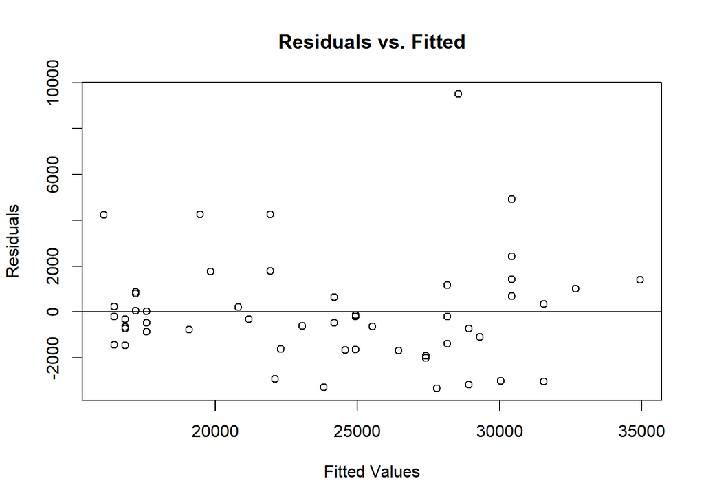

```r
plot(salary_lm$fitted.values, salary_lm$residuals, xlab="Fitted Values", ylab="Residuals", main="Residuals vs. Fitted")
abline(h=0)
```

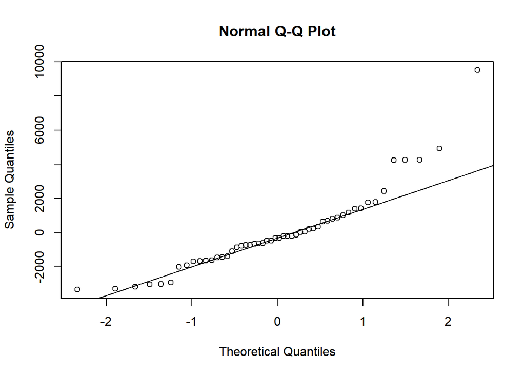

```r
qqnorm(salary_lm$residuals)
qqline(salary_lm$residuals)
```